# EDA part 1

First step of EDA, details below

Firza Riany

8/17/2020

# Description.

The general aim of the study was to find the genetic potential of black poplar’s resistance (*Populus nigra*) when they are infected by rust fungi.

Before proceeding to a more sophisticated modeling, I conducted an Exploratory Data Analysis (EDA) to gather the initial insights from the dataset.

**About the raw dataset and the species used**

The raw data consists of the measurement in the lab for poplar resistance.

The variables needed in the analysis were:  
- **Latent period, coded as Laten**  
- **Number of spores, coded as NbSS**  
_ **Size of spores, coded as Taiil**

Together, they are called “resistance components”.

The spesies is black poplar (*Populus nigra*) that was collected from several natural populations and sources in Western Europe.

**Experimental design**

Note. not all variables are going to be used, we will see as we proceed through this script.

The objectives of this first step of prelim analysis were:

## Objectives.

1. Check the resistant vs susceptible individuals.
2. Understand the global distribution of the resistance components.
3. Understand the variability in the resistance components between the rust types.

# Preparation (libraries, working directory, data set).

```r
# Libraries
library(plyr)  # Create a frequency table of resistant vs susceptible individuals
library(naniar)  # Replace values with NA
library(ggplot2)  # Make graphs
library(ggpubr)  # Arrange ggplot graphs in columns and rows

# Loading the raw data set ----
rust_test1 = read.delim2("B4est_test1_LectureJ13_J14_commented.txt", na = "NA")

# Selection of columns ----
test1_selec = rust_test1[ ,-c(12, 13, 15)]  # getting only the columns that we need
```

In the raw dataset I had 15 variables. I did not need all these 15 variables, so for simplicity, I selected only the variables that I needed. The preview of the first 5 observation in the dataset with the variables I needed is shown below:

```r
head(test1_selec)
```

```
##                 Block Strain Genotype X  Y Laten_24.02.15_gp NbSS_24.02.15_gp
## 1 B4est_1_Bloc_1-28x3 09AX27     N-35 1 13              11.0               13
## 2 B4est_1_Bloc_1-28x3 09AX27   NOH-13 2 13               9.0                6
## 3 B4est_1_Bloc_1-28x3 09AX27      N-1 3 13              13.0                2
## 4 B4est_1_Bloc_1-28x3 09AX27    6-A18 4 13               9.5                4
## 5 B4est_1_Bloc_1-28x3 09AX27   SSN-01 5 13              12.5                2
## 6 B4est_1_Bloc_1-28x3 09AX27   BDX-09 6 13              -5.0                0
##   NbSnS_24.02.15_gp NbSO_24.02.15_gp NbPtN_24.02.15_gp Taill_05.08.20_gp
## 1                 0                1                 0                 5
## 2                 0                8                 0                 4
## 3                 2                6                 3                 2
## 4                 0                8                 0                 5
## 5                 1                6                 0                 1
## 6                 3               11                 0                 0
##   points.noirs.avant.le.test
## 1                         NA
## 2                         NA
## 3                         NA
## 4                         NA
## 5                         NA
## 6                         NA
```

# Checking the resistant vs susceptible individuals.

This step will result in two groups of individuals; resistant and susceptible individuals.

*Resistant individuals are the individuals that are not interacting with the pathogen, thus do not have symptoms.*

*Susceptible individuals are the individuals that are interacting with the pathogen, thus causing symptoms.*

```r
# Subsetting the raw dataset by pathogen

test1_09AX27 = test1_selec[which(test1_selec$Strain == "09AX27"),]
test1_93JE3 = test1_selec[which(test1_selec$Strain == "93JE3"),]
test1_P72 = test1_selec[which(test1_selec$Strain == "P72"),]

# From control (Genotype == Robusta) and discriminants (Genotype == discrim$Discrim)

discrim = read.table("Tab_discrim_vir.txt",
                      header = TRUE,
                      row.names = NULL)

# Pathogen 09AX27

# Create a new column to differentiate normal individuals from control

test1_09AX27[ ,13] = "NA"

for (i in c(1:nrow(test1_09AX27))){
  if(test1_09AX27$Genotype[i] %in% discrim$Discrim)  # if the genotype name in 09AX27 is the same as those in discrim names in discriminant file
    test1_09AX27[i,13] = "discrim"  # then print discrim in each row of column 13

  if(test1_09AX27$Genotype[i] == "Robusta")  # if the genotype name is robusta
    test1_09AX27[i,13] = "control"  # then print control in each row of column 13
}

# Before graphical inspection, paste the label resistant and susceptible to the relevant individuals

test1_09AX27_nodisc = test1_09AX27[-which(test1_09AX27[ ,13] %in%
                                             c("control", "discrim")), ]

names(test1_09AX27_nodisc)[13] = "Res_vs_sus"

# -5 is a code for "non-measurable" observation, meaning that the individual did not show symptoms at all

for (i in c(1:nrow(test1_09AX27_nodisc))) {
  if(test1_09AX27_nodisc$Laten_24.02.15_gp[i] == -5)
    test1_09AX27_nodisc[i,13] = "Resistant"

  if(test1_09AX27_nodisc$Laten_24.02.15_gp[i] != -5)
    test1_09AX27_nodisc[i,13] = "Susceptible"
}

# Graphical inspection resistant vs susceptible individuals

resist_09AX27 = ggplot(test1_09AX27_nodisc, aes(x = Res_vs_sus)) +
  geom_bar(aes(fill = Res_vs_sus)) +
  geom_text(stat = "count", aes(label = ..count..), vjust = 0.25) +
  labs(title = "Pathogen = 09AX27",
       x = "Resistant vs Susceptibe",
       y = "Counts") +
  scale_fill_manual(values = c("#87CEEB", "#FF6A6A"),
                    breaks = c("Resistant", "Susceptible"),
                    name = "Resistant vs Susceptible",
                    labels = c("Resistant", "Susceptible")) +
  theme_classic() +
  theme(axis.title.x = element_blank(),
        legend.position = "none")
```

```r
# Pathogen 09AX27

# Create a new column to differentiate normal individuals from discriminants
# and control (subject for inspection)

# From control (Genotype == Robusta) and discriminants (Genotype == discrim$Discrim)

test1_93JE3[ ,13] = "NA"

for (i in c(1:nrow(test1_93JE3))){

  if(test1_93JE3$Genotype[i] %in% discrim$Discrim)
    test1_93JE3[i,13] = "discrim"

  if(test1_93JE3$Genotype[i] == "Robusta")
    test1_93JE3[i,13] = "control"
}

# Before graphical inspection, paste the label resistant and susceptible to
# the relevant individuals

test1_93JE3_nodisc = test1_93JE3[-which(test1_93JE3[ ,13] %in%
                                           c("control", "discrim")), ]

names(test1_93JE3_nodisc)[13] = "Res_vs_sus"

for (i in c(1:nrow(test1_93JE3_nodisc))) {

  if(test1_93JE3_nodisc$Laten_24.02.15_gp[i] == -5)
    test1_93JE3_nodisc[i,13] = "Resistant"


  if(test1_93JE3_nodisc$Laten_24.02.15_gp[i] != -5)
    test1_93JE3_nodisc[i,13] = "Susceptible"
}

# Graphical inspection resistant vs susceptible individuals

resist_93JE3 = ggplot(test1_93JE3_nodisc, aes(x = Res_vs_sus)) +
  geom_bar(aes(fill = Res_vs_sus)) +
  geom_text(stat = "count", aes(label = ..count..), vjust = 0.25) +
  labs(title = "Pathogen = 09AX27",
       x = "Resistant vs Susceptibe",
       y = "Counts") +
  scale_fill_manual(values = c("#87CEEB", "#FF6A6A"),
                    breaks = c("Resistant", "Susceptible"),
                    name = "Resistant vs Susceptible",
                    labels = c("Resistant", "Susceptible")) +
  theme_classic() +
  theme(axis.title.x = element_blank(),
        legend.position = "none")
```

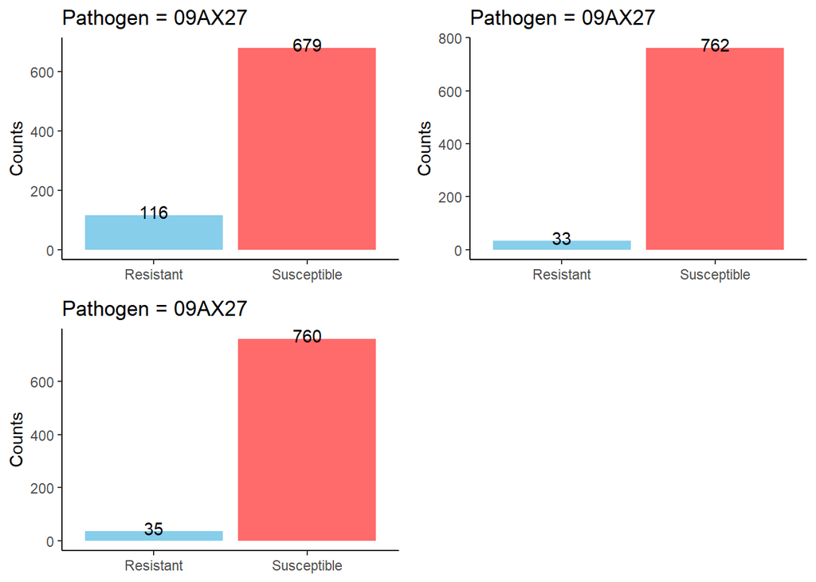

```r
# Pathogen 09AX27

# Create a new column to differentiate normal individuals from discriminants
# and control (subject for inspection)

# From control (Genotype == Robusta) and discriminants (Genotype == discrim$Discrim)

test1_P72[ ,13] = "NA"

for (i in c(1:nrow(test1_P72))){

  if(test1_P72$Genotype[i] %in% discrim$Discrim)
    test1_P72[i,13] = "discrim"

  if(test1_P72$Genotype[i] == "Robusta")
    test1_P72[i,13] = "control"
}

# Before graphical inspection, paste the label resistant and susceptible to
# the relevant individuals

test1_P72_nodisc = test1_P72[-which(test1_P72[ ,13] %in%
                                       c("control", "discrim")), ]

names(test1_P72_nodisc)[13] = "Res_vs_sus"

for (i in c(1:nrow(test1_P72_nodisc))) {

  if(test1_P72_nodisc$Laten_24.02.15_gp[i] == -5)
    test1_P72_nodisc[i,13] = "Resistant"

  if(test1_P72_nodisc$Laten_24.02.15_gp[i] != -5)
    test1_P72_nodisc[i,13] = "Susceptible"
}

# Graphical inspection resistant vs susceptible individuals

resist_P72 = ggplot(test1_P72_nodisc, aes(x = Res_vs_sus)) +
  geom_bar(aes(fill = Res_vs_sus)) +
  geom_text(stat = "count", aes(label = ..count..), vjust = 0.25) +
  labs(title = "Pathogen = 09AX27",
       x = "Resistant vs Susceptibe",
       y = "Counts") +
  scale_fill_manual(values = c("#87CEEB", "#FF6A6A"),
                    breaks = c("Resistant", "Susceptible"),
                    name = "Resistant vs Susceptible",
                    labels = c("Resistant", "Susceptible")) +
  theme_classic() +
  theme(axis.title.x = element_blank(),
        legend.position = "none")

# Combining the plots

res_vs_sus = ggpubr::ggarrange(resist_09AX27, resist_93JE3, resist_P72)

res_vs_sus
```

Strictly speaking, it is rather tricky to say that these 700 poplars were susceptible. It is more effective to say that these 700 poplars were actively interacting with the pathogen, while the rest were not really interacting with the pathogen. When the poplars are interactive, it means that they can behave differently or they can fight the pathogen with different abilities. Let’s stick with this definition now.

## Counting the completely resistant individuals (meaning that they are not interacting with the pathogen)

```r
# Calculating the numbers of resistant individuals for pathogen 09AX27

incomp_09AX27 = plyr::count(test1_09AX27_nodisc$Genotype[
  which(test1_09AX27_nodisc$Laten_24.02.15_gp == -5)])

# Calculating the numbers of resistant individuals for pathogen 93JE3

incomp_93JE3 = plyr::count(test1_93JE3_nodisc$Genotype[
  which(test1_93JE3_nodisc$Laten_24.02.15_gp == -5)])

# Calculating the numbers of resistant individuals for pathogen P72

incomp_P72 = plyr::count(test1_P72_nodisc$Genotype[
  which(test1_P72_nodisc$Laten_24.02.15_gp == -5)])

# Finding the individuals that are resistant across the pathogens

common_resist = data.frame(intersect(incomp_09AX27$x, incomp_93JE3$x))

common_final = data.frame(intersect(common_resist$intersect.incomp_09AX27.x..incomp_93JE3.x., incomp_P72$x))

names(common_final)[1] = "resistant across the pathogens"

common_final
```

```
##   resistant across the pathogens
## 1                         BDX-03
## 2                           N-66
## 3                        NL-1210
```

Turned out three poplar individuals were completely resistant across all the pathogens. It means that they were completely not interacting with the pathogens. Pathogens’ activities were indifferent to them.

# Graphical distribution of the resistance components

After inspecting which individuals that were resistant and which were susceptible, I wanted to look into my data as a whole. So, before continuing to data cleaning and EDA, I wanted to see the overall distribution of my dataset.

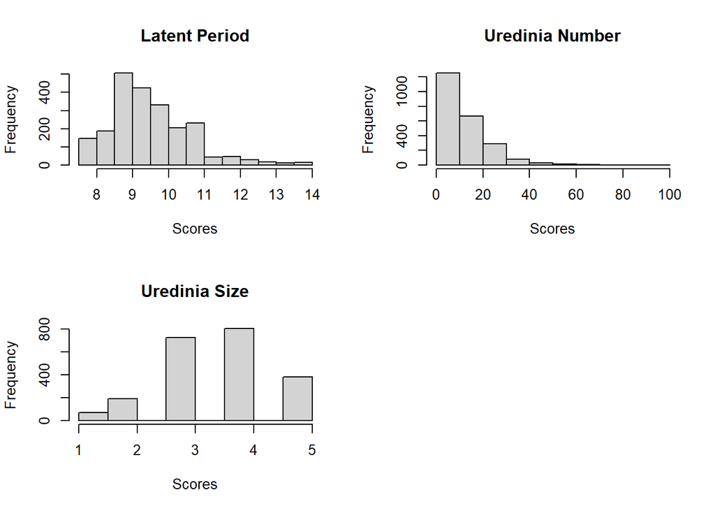

```r
# Some preparation

test1_selec_NA = test1_selec  # creating a new data frame to avoid confusion

# Replacing -5 to NA because -5 was the code for missing data during
# the experiment

test1_selec_NA =  test1_selec_NA %>%
  naniar::replace_with_na(replace = list(Laten_24.02.15_gp = -5,
                                         NbSS_24.02.15_gp = -5,
                                         NbSO_24.02.15_gp = -5,
                                         NbPtN_24.02.15_gp = -5,
                                         Taill_05.08.20_gp = c(-5,0)))

## Total uredinia number = adding NbSS and NbSoS

test1_selec_NA$total_NbSS = test1_selec_NA$NbSS_24.02.15_gp +
  test1_selec_NA$NbSO_24.02.15_gp

## Total black points = substracting NbPtN by point noires avant le test

test1_selec_NA$PtN_real = test1_selec_NA$NbPtN_24.02.15_gp -
  test1_selec_NA$points.noirs.avant.le.test

# Replacing negative values in PtN_real to 0

test1_selec_NA$PtN_real = replace(test1_selec_NA$PtN_real,
                                   test1_selec_NA$PtN_real < 0, 0)

## Removing the discriminants and the control

test1_selec_NA[ ,15] = "NA"

for (i in c(1:nrow(test1_selec_NA))){

  if(test1_selec_NA$Genotype[i] %in% discrim$Discrim)
    test1_selec_NA[i,15] = "discrim"

  if(test1_selec_NA$Genotype[i] == "Robusta")
    test1_selec_NA[i,15] = "control"
}

test1_NA_nodisc = test1_selec_NA[-which(test1_selec_NA[ ,15] %in%
                                           c("control", "discrim")), ]

## Histogram of each trait

par(mfrow = c(2,2))

test1_loop = data.frame("LP" = test1_NA_nodisc$Laten_24.02.15_gp,
                         "UN" = test1_NA_nodisc$total_NbSS,
                         "US" = test1_NA_nodisc$Taill_05.08.20_gp)

names(test1_loop)[1:3] = c("Latent Period", "Uredinia Number", "Uredinia Size")

loop.vector = 1:3

for (i in loop.vector){
  x = test1_loop[,i]
  title = names(test1_loop[i])
  hist(x,
       main = title,
       xlab = "Scores")
}
```

**Latent period.** By definition, it is the time needed for the individuals to start showing the first symptoms of infection. When poplars were infected with rust, the symptom would be yellow spores that are populating poplar’s leaves. In my study, most poplars started having this symptom on the 9th, 10th, and 11th day after inoculation (i.e. exposure to the pathogen).

**Uredinia number**. By definition, it is the number of spores that are populating the poplar’s leaves. On the day 14 after inoculation, I counted the uredinia number. Most poplars had 1 - 40 spores on their leaves by this day.

**Uredinia size**. By definition, it is the size of the spores that are populating the poplar’s leaves. On the day 14, I evaluated the uredinia size by scoring it. The score goes from 1 (the smallest) to 5 (the largest). In my study, most poplars had spores with sizes scored 3 - 4.

Note that in this part I just summarized the distribution of the resistance components from my dataset as a whole.

Remember that I had 5 blocks which served as repetitions to avoid bias. In this section, I acknowledged the individuals in 5 blocks as different individuals. The idea was to see how they were behaving in general and what distribution I could expect from my data. However, after I clean the data, I would get one value averaged across 5 blocks for an individual’s resistance components.

# Graphical distribution of the resistance components depending on the pathogen types

Now I want to crosscheck the previous distribution (that was not considering the different pathogens I used) with the following distribution where I sparse the distribution based on the pathogens. Will the resistance components have the same distribution as before?

```r
## Subsetting the clean dataset based on pathogen

s09AX27_clean = test1_NA_nodisc[which(test1_NA_nodisc$Strain == "09AX27"),]
s93JE3_clean = test1_NA_nodisc[which(test1_NA_nodisc$Strain == "93JE3"),]
sP72_clean = test1_NA_nodisc[which(test1_NA_nodisc$Strain == "P72"),]
```

## Graphical inspection pathogen 09AX27

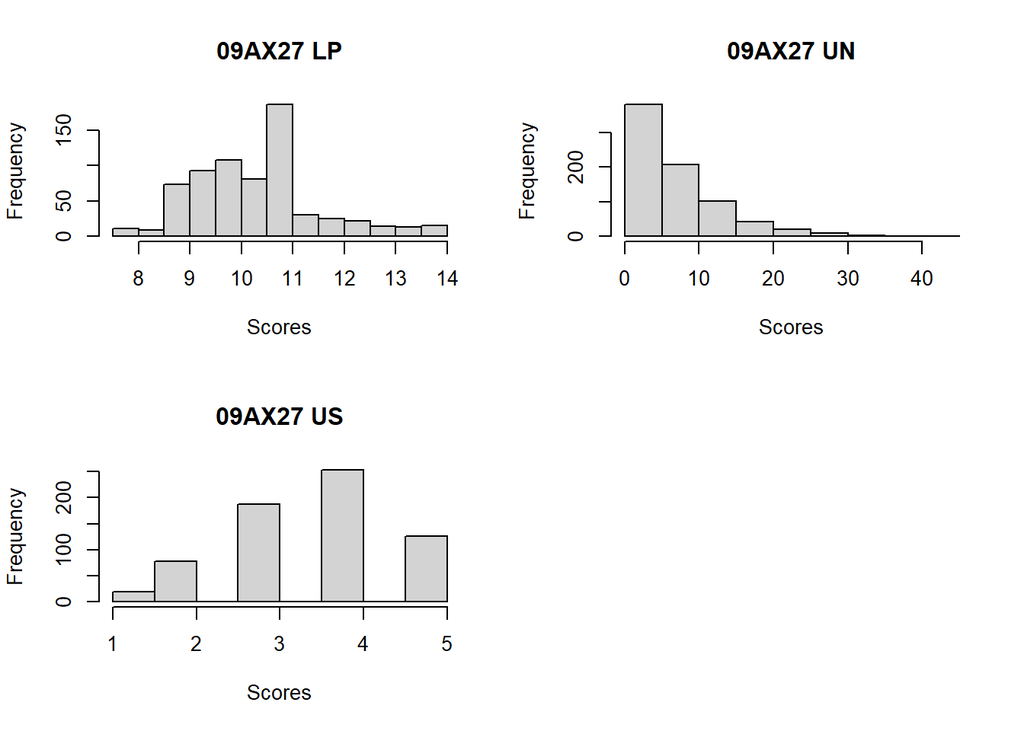

```r
s09AX27_loop = data.frame("LP" = s09AX27_clean$Laten_24.02.15_gp,
                           "UN" = s09AX27_clean$total_NbSS,
                           "US" = s09AX27_clean$Taill_05.08.20_gp)
loop.vector = 1:3

par(mfrow = c(2,2))

for (i in loop.vector){
  x = s09AX27_loop[,i]
  title = names(s09AX27_loop[i])
  hist(x,
       main = paste("09AX27", title),
       xlab = "Scores")
}
```

## Graphical inspection pathogen 93JE3

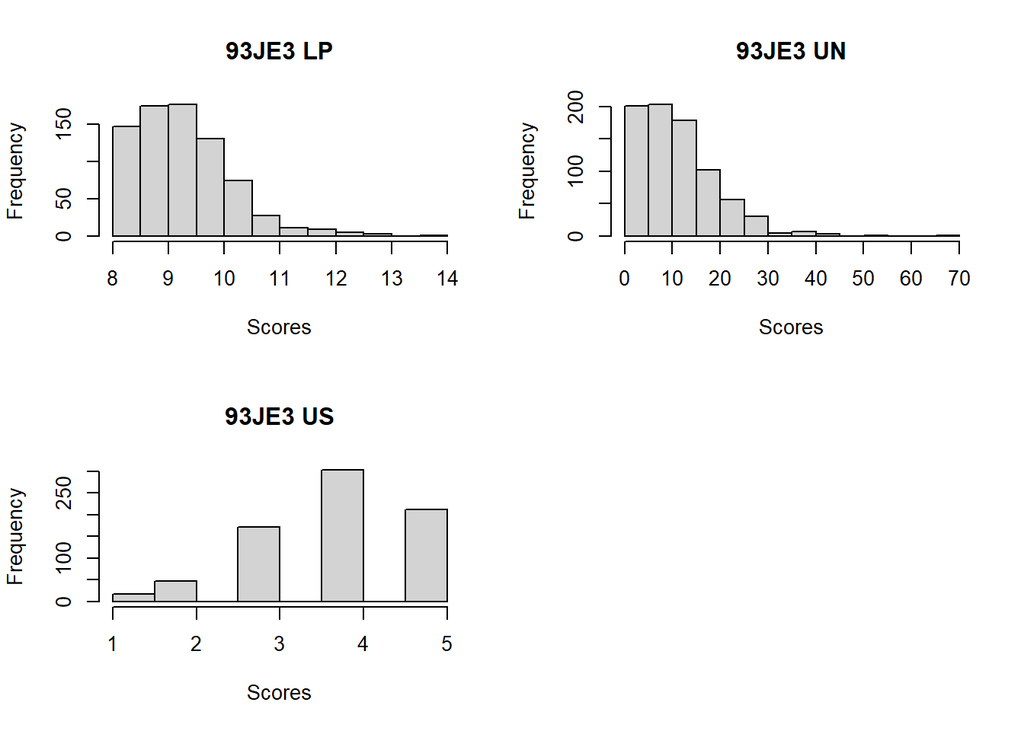

```r
s93JE3_loop = data.frame("LP" = s93JE3_clean$Laten_24.02.15_gp,
                          "UN" = s93JE3_clean$total_NbSS,
                          "US" = s93JE3_clean$Taill_05.08.20_gp)

par(mfrow = c(2,2))

for (i in loop.vector){
  x = s93JE3_loop[,i]
  title = names(s93JE3_loop[i])
  hist(x,
       main = paste("93JE3", title),
       xlab = "Scores")
}
```

## Graphical inspection pathogen P72

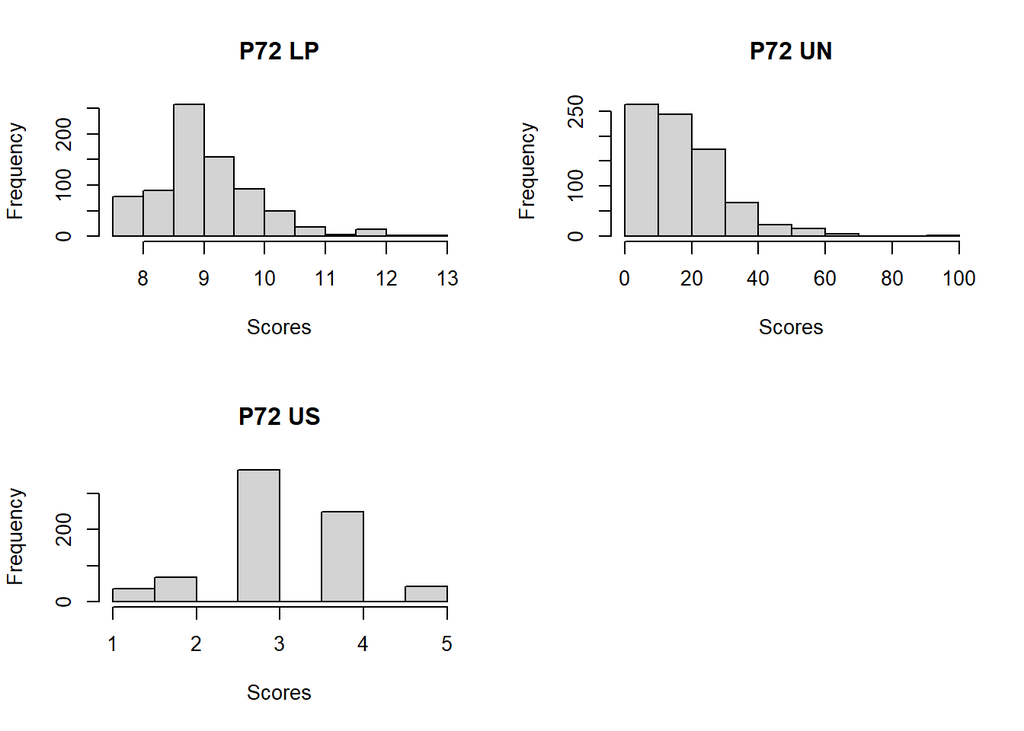

```r
sP72_loop = data.frame("LP" = sP72_clean$Laten_24.02.15_gp,
                        "UN" = sP72_clean$total_NbSS,
                        "US" = sP72_clean$Taill_05.08.20_gp)

par(mfrow = c(2,2))

for (i in loop.vector){
  x = sP72_loop[,i]
  title = names(sP72_loop[i])
  hist(x,
       main = paste("P72", title),
       xlab = "Scores")
}
```